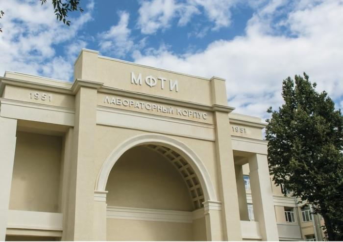

[Московский физико-технический институт](http://mipt.ru/) является одним из ведущих вузов страны и входит в основные рейтинги лучших университетов мира. Институт обладает не только богатой историей – основателями и профессорами института были Нобелевские лауреаты П.Л. Капица, Л.Д. Ландау и Н.Н. Семенов, – но и большой научно-исследовательской базой.

Основой образования в МФТИ является уникальная «система Физтеха», сформулированная П.Л. Капицей:

- кропотливый отбор одаренных и склонных к творческой работе абитуриентов;
- участие в обучении ведущих научных работников и в тесном контакте с ними;
- индивидуальный подход к отдельным студентам с целью развития их творческих задатков;
- воспитание с первых шагов в атмосфере технических исследований и конструктивного творчества с использованием потенциала лучших лабораторий страны.

Среди выпускников МФТИ — нобелевские лауреаты Андрей Гейм и Константин Новоселов, основатель компании ABBYY Давид Ян, один из авторов архитектурных принципов построения вычислительных комплексов Борис Бабаян и др.

### **ТОП-10 фактов об МФТИ**

1. 10 нобелевских лауреатов среди профессоров и выпускников
2. 6 200 студентов из 28 стран
3. Более 90 преподавателей – член-корреспонденты и академики РАН
4. Более 50 научных лабораторий
5. Входит в ТОП-3 Российских вузов (в рейтингах качества приема НИУ ВШЭ и МИА “Россия сегодня”, RAEX, Interfax)
6. Входит в ТОП-10 в рейтинге QS университетов стран развивающейся Европы и Центральной Азии
7. Один из двух российских вузов, вошедших в предметный рейтинг ARWU по физике
8. Лидер в рейтинге вузов по максимальному проходному баллу ЕГЭ среди поступивших
9. 5 выпускников Физтеха входят в российский рейтинг Forbes (А. Абрамов, Александр Фролов, Константин Григоришин, Вадим Якунин, Илья Зубарев)
10. Выпускники МФТИ, работающие в IT, получают самые высокие в этой отрасли зарплаты по результатам рейтинга Superjob

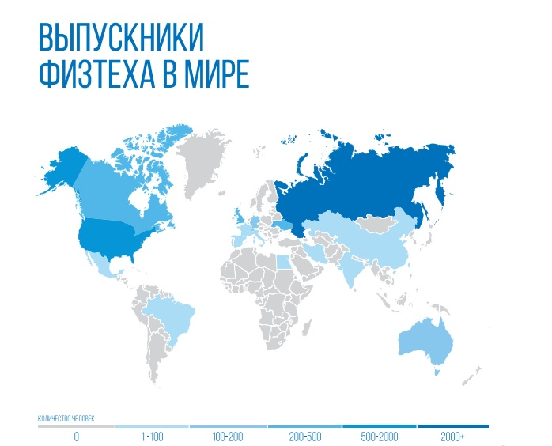